# Tarea2

## Área académica de Ingeniería en Computadores

## CE - 5506 Introducción al Reconocimiento de Patrones

## Tarea #2

## Estudiantes: Cambronero Ureña Aldo - 2018099813 Agüero Sandí Johnny - 2020027766

## Profesor: Jason Leiton Jimenez

## Grupo 1

## IS $-$ 2023

## Primera Parte

### 1. Analice el código de regresión lineal visto en clase, el cual se encuentra en tecdigital con el nombre “RegresionLineal.ipynb”

```python
import numpy as np
import matplotlib.pyplot as plt
import pandas as pd
import random
import time
```

```python
class LinearRegression:

    def __init__(self, n_features):
        self.W = np.random.normal(-1,1,(n_features,1)) #weights
        self.b = np.random.rand(1) #intercept

    def descent(self, delta_W, delta_b, learning_rate):
        #updating the weights with the calculated gradients
        self.W -= learning_rate*delta_W
        self.b -= learning_rate*delta_b

    def derivatives(self, X, Y):
        #partial derivative of cost w.r.t the weights
        delta_W = np.sum(np.multiply(((np.matmul(X,self.W)+self.b)-Y), X))*2/X.shape[0]
        #partial derivative of cost w.r.t the intercept
        delta_b = np.sum(((np.matmul(X,self.W)+self.b)-Y))*2/X.shape[0]
        return delta_W, delta_b

    #fit
    def train(self, X, Y, epochs=50, learning_rate=0.1):
        X = np.array(X).reshape(-1,1)
        Y = np.array(Y).reshape(-1,1)
        for i in range(epochs):
            delta_W, delta_b = self.derivatives(X, Y)
            self.descent(delta_W, delta_b, learning_rate)
        return self.W, self.b
    def predict(self, X):
        #print(X.shape, X.reshape(-1,1).shape)
        product = np.matmul(np.array(X).reshape(-1,1),self.W)+self.b
        return product
```

### 2. Busque un set de datos básico (no imágenes) libre y carguelo. Posteriormente muestre un los primeros 10 datos con sus etiquetas.

```python
df = pd.read_csv("https://raw.githubusercontent.com/aasthac67/Insurance_Charges_Prediction/main/insurance.csv")
print(df.head(10))
print(df.shape)
```

```
   age     sex     bmi  children smoker     region      charges
0   19  female  27.900         0    yes  southwest  16884.92400
1   18    male  33.770         1     no  southeast   1725.55230
2   28    male  33.000         3     no  southeast   4449.46200
3   33    male  22.705         0     no  northwest  21984.47061
4   32    male  28.880         0     no  northwest   3866.85520
5   31  female  25.740         0     no  southeast   3756.62160
6   46  female  33.440         1     no  southeast   8240.58960
7   37  female  27.740         3     no  northwest   7281.50560
8   37    male  29.830         2     no  northeast   6406.41070
9   60  female  25.840         0     no  northwest  28923.13692
(1338, 7)
```

### 3. Realice el proceso de feature engeneering.

```python
x = (df['age']-df['age'].mean())/df['age'].std() #standardization of the dataset
y = (df["charges"]-df['charges'].mean())/df["charges"].std()
x.shape, y.shape
```

```
((1338,), (1338,))
```

### 4. Modifique el código proporcionado para que el modelo genere la regresión lineal sobre el set de datos elegido.

```python
reg = LinearRegression(n_features=1)
```

```
[0.29900819] -3.515609013498954e-17
```

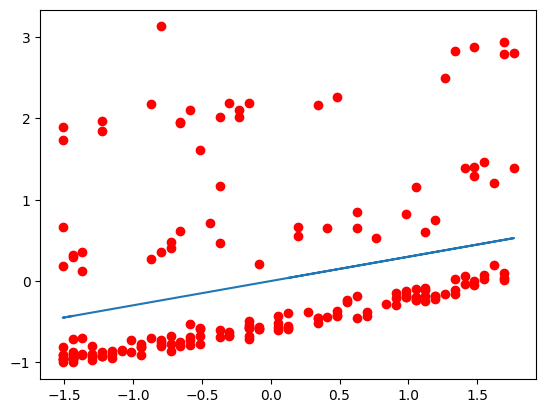

```python
params = reg.train(x, y, epochs=500, learning_rate=0.3)
print(params[0][-1], params[1][-1])
plt.scatter(x[:180], y[:180], color='red')
pred = reg.predict(np.array(x[:180]))
plt.plot(x[:180], pred[:180])
```

## Segunda Parte

### 1. Tome el código modificado y genere el mismo código sin utilizar bibliotecas de procesamiento matemático para las operaciones matriciales, es decir, debe hacerlo con solo listas.

```python
class LinearRegression_Lists:
    def __init__(self, n_features):
        self.W = [random.normalvariate(-1, 1) for _ in range(n_features)] # weights
        self.b = random.random() # intercept

    def descent(self, delta_W, delta_b, learning_rate):
        # updating the weights with the calculated gradients
        self.W = [w - learning_rate * dw for w, dw in zip(self.W, delta_W)]
        self.b -= learning_rate * delta_b

    def derivatives(self, X, Y):
        # partial derivative of cost w.r.t the weights
        delta_W = [2 * (np.dot(X, self.W)[i] + self.b - Y[i]) * X[i] / len(X) for i in range(len(X[0]))]
        # partial derivative of cost w.r.t the intercept
        delta_b = 2 * np.sum(np.dot(X, self.W) + self.b - Y) / len(X)
        return delta_W, delta_b

    def train(self, X, Y, epochs=50, learning_rate=0.1):
        X = [[x] for x in X]
        Y = [[y] for y in Y]
        for i in range(epochs):
            delta_W, delta_b = self.derivatives(X, Y)
            self.descent(delta_W, delta_b, learning_rate)
        return self.W, self.b

    def predict(self, X):
        product = [sum([X[i] * self.W[j] for j in range(len(self.W))]) + [self.b] for i in range(len(X))]
        return product
```

### 2. Ahora realice el código de la primera parte utilizando únicamente Pytorch (tensores).

```python
import torch

class LinearRegression_Torch:

    def __init__(self, n_features):
        self.W = torch.randn(n_features, 1, requires_grad=True) #weights
        self.b = torch.randn(1, requires_grad=True) #intercept

    def descent(self, delta_W, delta_b, learning_rate):
        #updating the weights with the calculated gradients
        self.W.data -= learning_rate*delta_W.data
        self.b.data -= learning_rate*delta_b.data

    def derivatives(self, X, Y):
        #partial derivative of cost w.r.t the weights
        delta_W = torch.sum(torch.mul(((torch.matmul(X,self.W)+self.b)-Y), X))*2/X.shape[0]
        #partial derivative of cost w.r.t the intercept
        delta_b = torch.sum(((torch.matmul(X,self.W)+self.b)-Y))*2/X.shape[0]
        return delta_W, delta_b

    #fit
    def train(self, X, Y, epochs=50, learning_rate=0.1):
        X = torch.tensor(X, dtype=torch.float32).reshape(-1,1)
        Y = torch.tensor(Y, dtype=torch.float32).reshape(-1,1)
        for i in range(epochs):
            delta_W, delta_b = self.derivatives(X, Y)
            self.descent(delta_W, delta_b, learning_rate)
        return self.W.data, self.b.data

    def predict(self, X):
        product = torch.matmul(torch.tensor(X, dtype=torch.float32).reshape(-1,1),self.W)+self.b
        return product.data
```

### 3. Ejecute ambos códigos y haga comparaciones en los tiempos de ejecución (Realice este paso con el set de datos elegido y con uno creado por cada grupo).

#### Set de datos elegido

```
tensor([0.2990]) tensor(7.1935e-09)
Tiempo de ejecución:  0.08247852325439453
```

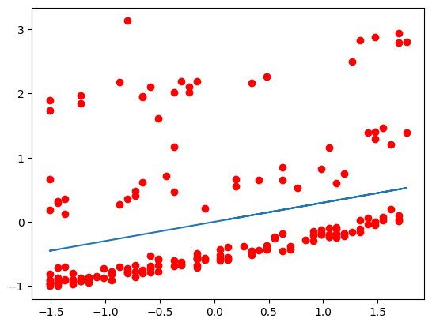

```python
reg_torch = LinearRegression_Torch(n_features=1)
start_time_torch_1 = time.time()

params_torch = reg_torch.train(x, y, epochs=500, learning_rate=0.3)
print(params_torch[0][-1], params_torch[1][-1])

plt.scatter(x[:180], y[:180], color='red')
pred_torch = reg_torch.predict(np.array(x[:180]))
plt.plot(x[:180], pred_torch[:180])

end_time_torch_1 = time.time()

time_torch_1 = end_time_torch_1 - start_time_torch_1
print('Tiempo de ejecución: ', time_torch_1)
```

```
[-1.60749705] -3.236923981925362e-16
Tiempo de ejecución:  0.5074713230133057
```

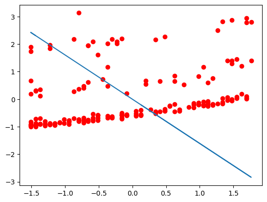

```python
reg_lists = LinearRegression_Lists(n_features=1)
start_time_lists_1 = time.time()

params_lists = reg_lists.train(x, y, epochs=500, learning_rate=0.3)
print(params_lists[0][-1], params_lists[1])

plt.scatter(x[:180], y[:180], color='red')
pred_lists = reg_lists.predict(np.array(x[:180]))
plt.plot(x[:180], pred_lists[:180])

end_time_lists_1 = time.time()
time_lists_1 = end_time_lists_1 - start_time_lists_1
print('Tiempo de ejecución: ', time_lists_1)
```

#### Se selecciona el archivo con el dataset creado por nosotros. Dentro de esta carpeta se encuentra un script de python que genera valores aleatorios y los almacena dentro del archivo ejemplo

```python
data = pd.read_csv("ejemplo.csv")
print(data.head(10))
print(data.shape)
```

```
   ID de usuario  Edad  Ingresos
0              1    45     34936
1              2    39     60455
2              3    51     28843
3              4    19     52970
4              5    34     73357
5              6    26     57915
6              7    18     62653
7              8    37     86714
8              9    23     47771
9             10    58     91024
(1337, 3)
```

```python
data_x = (data['Edad']-data['Edad'].mean())/data['Edad'].std() #standardization of the dataset
data_y = (data["Ingresos"]-data['Ingresos'].mean())/data["Ingresos"].std()
data_x.shape, data_y.shape
```

```
((1337,), (1337,))
```

```
tensor([-0.0413]) tensor(-1.2675e-09)
Tiempo de ejecución:  0.09524130821228027
```

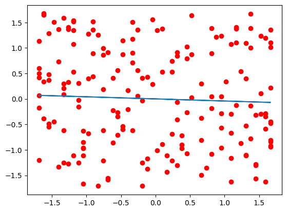

```python
reg_torch = LinearRegression_Torch(n_features=1)
start_time_torch_2 = time.time()

params_torch = reg_torch.train(data_x, data_y, epochs=500, learning_rate=0.3)
print(params_torch[0][-1], params_torch[1][-1])

plt.scatter(data_x[:180], data_y[:180], color='red')
pred_torch = reg_torch.predict(np.array(data_x[:180]))
plt.plot(data_x[:180], pred_torch[:180])

end_time_torch_2 = time.time()
time_torch_2 = end_time_torch_2 - start_time_torch_2
print('Tiempo de ejecución: ', time_torch_2)
```

```
[-0.66356917] -1.2175424606915073e-16
Tiempo de ejecución:  0.5914421081542969
```

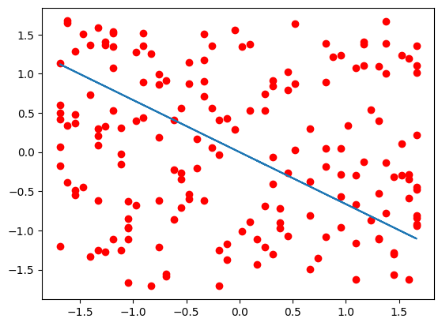

```python
reg_lists = LinearRegression_Lists(n_features=1)
start_time_lists_2 = time.time()

params_lists = reg_lists.train(data_x, data_y, epochs=500, learning_rate=0.3)
print(params_lists[0][-1], params_lists[1])

plt.scatter(data_x[:180], data_y[:180], color='red')
pred_lists = reg_lists.predict(np.array(data_x[:180]))
plt.plot(data_x[:180], pred_lists[:180])

end_time_lists_2 = time.time()
time_lists_2 = end_time_lists_2 - start_time_lists_2
print('Tiempo de ejecución: ', time_lists_2)
```